# Murray Logan's Stats Course

So the question is, do we need to look at the anova table? If we do, we need to ask for **Type 3 Sums of Squares**. First of all, before these can be fitted, we need to first make sure not every group is compared to the first group. So we need to make a contrast which is not the treatment

```r
contrasts(quinn$SEASON) <-contr.sum
contrasts(quinn$DENSITY) <- contr.sum
quin.lm <- lm(SQRTRECRUITS~DENSITY*SEASON,data=quinn)
Anova(quin.lm,type='III')
```

```
## Anova Table (Type III tests)
##
## Response: SQRTRECRUITS
##                Sum Sq Df  F value    Pr(>F)
## (Intercept)    539.72  1 529.0381 < 2.2e-16 ***
## DENSITY          6.48  1   6.3510   0.01659 *
## SEASON          90.64  3  29.6135 1.341e-09 ***
## DENSITY:SEASON  11.35  3   3.7098   0.02068 *
## Residuals       34.69 34
## ---
## Signif. codes:  0 '***' 0.001 '**' 0.01 '*' 0.05 '.' 0.1 ' ' 1
```

Conclusion is that there is a significant interaction between SEASON and DENSITY (this procedure will take some of the interaction effect away). Show this interaction

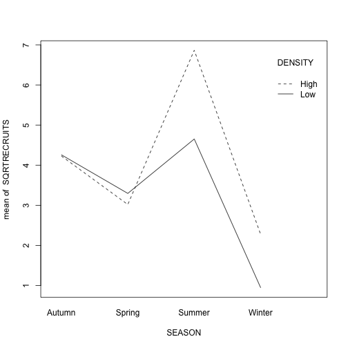

```r
with(quinn,interaction.plot(SEASON,DENSITY,SQRTRECRUITS))
```

So what do we do now? We need to divide the data. We can do 2 seperate ANOVAs, one for each density. Or we can run 4, 1 for each season.

```r
data.lm.summer <- lm(SQRTRECRUITS~DENSITY,data=subset(quinn,SEASON=='Summer'))
anova(data.lm.summer)
```

```
## Analysis of Variance Table
##
## Response: SQRTRECRUITS
##           Df  Sum Sq Mean Sq F value  Pr(>F)
## DENSITY    1 14.6974  14.697  17.665 0.00182 **
## Residuals 10  8.3199   0.832
## ---
## Signif. codes:  0 '***' 0.001 '**' 0.01 '*' 0.05 '.' 0.1 ' ' 1
```

```r
data.lm.autumn <- lm(SQRTRECRUITS~DENSITY,data=subset(quinn,SEASON=='Autumn'))
anova(data.lm.autumn)
```

```
## Analysis of Variance Table
##
## Response: SQRTRECRUITS
##           Df  Sum Sq Mean Sq F value Pr(>F)
## DENSITY    1  0.0022 0.00215  0.0016 0.9695
## Residuals  8 11.0713 1.38391
```

```r
data.lm.spring <- lm(SQRTRECRUITS~DENSITY,data=subset(quinn,SEASON=='Spring'))
anova(data.lm.spring)
```

```
## Analysis of Variance Table
##
## Response: SQRTRECRUITS
##           Df Sum Sq Mean Sq F value Pr(>F)
## DENSITY    1 0.2086 0.20856  0.2703 0.6157
## Residuals  9 6.9452 0.77169
```

```r
data.lm.winter <- lm(SQRTRECRUITS~DENSITY,data=subset(quinn,SEASON=='Winter'))
anova(data.lm.winter)
```

```
## Analysis of Variance Table
##
## Response: SQRTRECRUITS
##           Df Sum Sq Mean Sq F value Pr(>F)
## DENSITY    1 3.5356  3.5356  2.9638 0.1288
## Residuals  7 8.3505  1.1929
```

This is a perfectly fine way to deal with complex datasets

**Dealing with Heterogeneity**

```r
d2<-read.csv('D2.csv',strip.white=T)
head(d2)
```

```
##          y x
## 1 36.24128 A
## 2 41.10186 A
## 3 34.98623 A
## 4 49.57168 A
## 5 41.97705 A
## 6 35.07719 A
```

```r
summary(d2)
```

```
##        y         x
##  Min.   :29.29   A:10
##  1st Qu.:36.17   B:10
##  Median :40.89   C:10
##  Mean   :42.34   D:10
##  3rd Qu.:49.32   E:10
##  Max.   :56.84
```

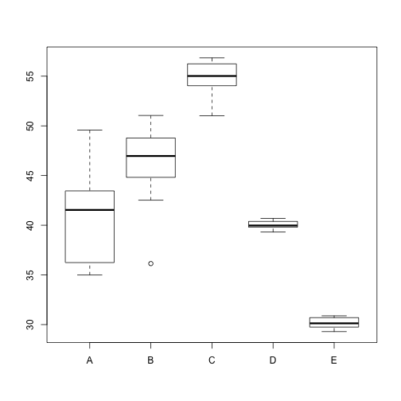

```r
boxplot(y~x,data=d2)
```

There is not necessarily a problem with normality. However, the variance between the groups is quite different (variance of A is much larger than D).

First let's see what happens if we analyze it the standard way

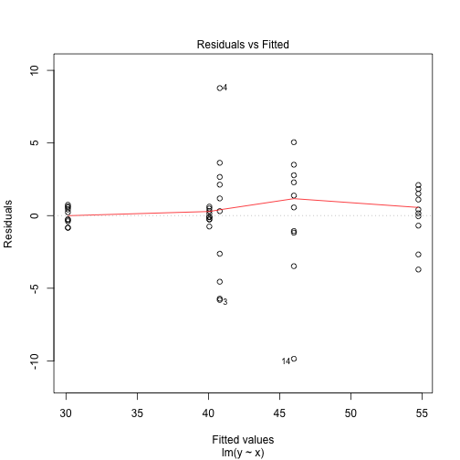

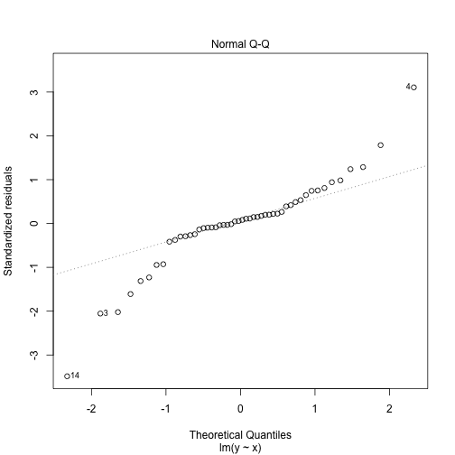

```r
d2.lm <- lm (y~x, data=d2)
plot(d2.lm,ask=F,which=1:2)
```

We are going to estimate the Maximum Likelihood off the data. Instead of lm we're going to use GLS. A GLS will first run an lm and then re-run the analysis to estimate the random effects. Finally, it will run again to update the fixed effects.

The difference between Maximum Likelyhood and Restricted ML: RML is more appropriate for estimating random effects. Residuals and variances are random effects. We want to estimate our variances correctly and thus we need to use RML.

```r
d2.gls <- gls(y~x, data=d2, method='REML')
summary(d2.gls)
```

```
## Generalized least squares fit by REML
##   Model: y ~ x
##   Data: d2
##        AIC      BIC    logLik
##   249.4968 260.3368 -118.7484
##
## Coefficients:
##                 Value Std.Error  t-value p-value
## (Intercept)  40.79322 0.9424249 43.28538  0.0000
## xB            5.20216 1.3327901  3.90321  0.0003
## xC           13.93944 1.3327901 10.45884  0.0000
## xD           -0.73285 1.3327901 -0.54986  0.5851
## xE          -10.65908 1.3327901 -7.99757  0.0000
##
##  Correlation:
##    (Intr) xB     xC     xD
## xB -0.707
## xC -0.707  0.500
## xD -0.707  0.500  0.500
## xE -0.707  0.500  0.500  0.500
##
## Standardized residuals:
##         Min          Q1         Med          Q3         Max
## -3.30653942 -0.24626108  0.06468242  0.39046918  2.94558782
##
## Residual standard error: 2.980209
## Degrees of freedom: 50 total; 45 residual
```

```r
anova(d2.gls)
```

```
## Denom. DF: 45
##             numDF   F-value p-value
## (Intercept)     1 10093.524  <.0001
## x               4    91.062  <.0001
```

When looking at residual plots, it is the standardized residuals we should care about more.

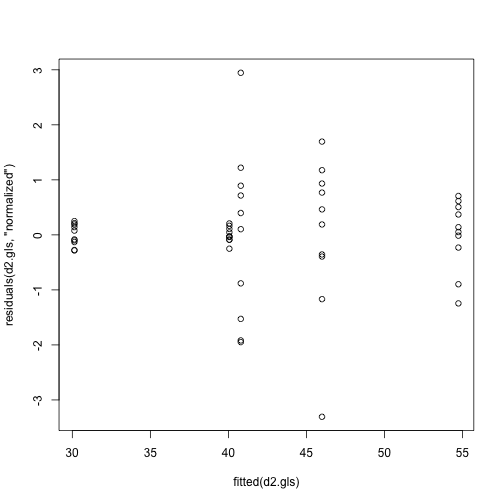

```r
plot(residuals(d2.gls,'normalized')~fitted(d2.gls))
```

Now let's do it with the correct correction. Instead of using the same variance each time, we're going to change the variance using the weights. This is how to correct for unequal variance. It will take the standard variance co-variance matrix and will multiply it by weights, which will tell it to produce a seperate co-variance matrix for each level of x.

```r
d2.gls1<-gls(y~x, data=d2, weights=varIdent(form=~1|x), method='REML')
```

If we use the normal residual plot, it looks like we didn't do anything.

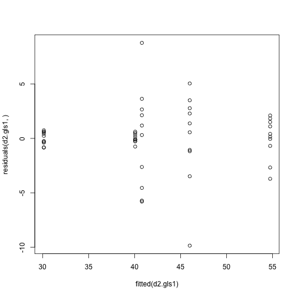

```r
plot(residuals(d2.gls1,)~fitted(d2.gls1))
```

However, if we look at the **standardized residual plot** we see a difference

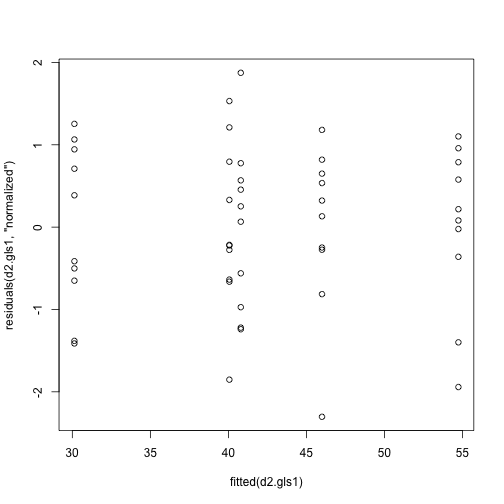

```r
plot(residuals(d2.gls1,'normalized')~fitted(d2.gls1))
```

Now look at the different levels of x

```r
summary(d2.gls1)
```

```
## Generalized least squares fit by REML
##   Model: y ~ x
##   Data: d2
##        AIC      BIC    logLik
##   199.2087 217.2753 -89.60435
##
## Variance function:
##  Structure: Different standard deviations per stratum
##  Formula: ~1 | x
##  Parameter estimates:
##          A          B          C          D          E
## 1.00000000 0.91342375 0.40807004 0.08631969 0.12720393
##
## Coefficients:
##                 Value Std.Error   t-value p-value
## (Intercept)  40.79322  1.481066 27.543153  0.0000
## xB            5.20216  2.005924  2.593399  0.0128
## xC           13.93944  1.599634  8.714142  0.0000
## xD           -0.73285  1.486573 -0.492981  0.6244
## xE          -10.65908  1.493000 -7.139371  0.0000
##
##  Correlation:
##    (Intr) xB     xC     xD
## xB -0.738
## xC -0.926  0.684
## xD -0.996  0.736  0.922
## xE -0.992  0.732  0.918  0.988
##
## Standardized residuals:
##        Min         Q1        Med         Q3        Max
## -2.3034239 -0.6178652  0.1064904  0.7596732  1.8743230
##
## Residual standard error: 4.683541
## Degrees of freedom: 50 total; 45 residual
```

Now, was this worth doing? The **wrong** way is to look if this is the result I wanted. We need to look at the AIC

```r
AIC(d2.gls,d2.gls1)
```

```
##         df      AIC
## d2.gls   6 249.4968
## d2.gls1 10 199.2087
```

We can also compare the logLikelihood

```r
anova(d2.gls,d2.gls1)
```

```
##         Model df      AIC      BIC     logLik   Test  L.Ratio p-value
## d2.gls      1  6 249.4968 260.3368 -118.74841
## d2.gls1     2 10 199.2087 217.2753  -89.60435 1 vs 2 58.28812  <.0001
```

This test confirms that the logLikelihood is also higher for the corrected model, and so we confirm it is a good step to correct for this.

# Day 2

**Linear Hierachical Models**

This is a linear model with separete covariance structure per block, and has fixed and random effects

```r
curdies <- read.csv('curdies.csv',strip.white=T)
head(curdies)
```

```
##   SEASON SITE   DUGESIA   S4DUGES
## 1 WINTER    1 0.6476829 0.8970995
## 2 WINTER    1 6.0961516 1.5713175
## 3 WINTER    1 1.3105639 1.0699526
## 4 WINTER    1 1.7252788 1.1460797
## 5 WINTER    1 1.4593867 1.0991136
## 6 WINTER    1 1.0575610 1.0140897
```

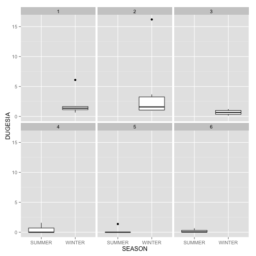

```r
curdies$SITE <-factor(curdies$SITE)
ggplot(curdies, aes(y=DUGESIA,x=SEASON)) + geom_boxplot() + facet_wrap(~SITE)
```

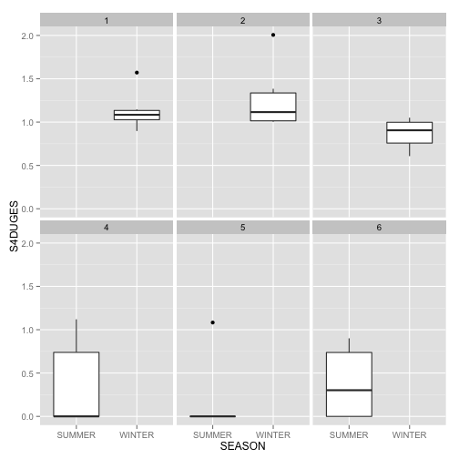

```r
ggplot(curdies, aes(y=S4DUGES,x=SEASON)) + geom_boxplot() + facet_wrap(~SITE)
```

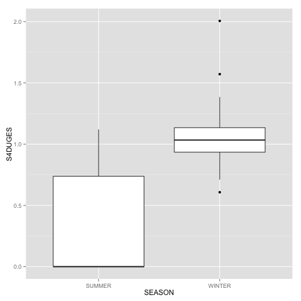

```r
ggplot(curdies, aes(y=S4DUGES,x=SEASON)) + geom_boxplot()
```

When testing assumptions, you need to look at the scale of replecations. The latter plot is thus wrong, as it doesn't show the averages for the replicates

```r
curdies.ag <- ddply(curdies, ~SEASON+SITE, numcolwise(mean))
curdies.ag
```

```
##   SEASON SITE   DUGESIA   S4DUGES
## 1 SUMMER    4 0.4190947 0.3508213
## 2 SUMMER    5 0.2290862 0.1804622
## 3 SUMMER    6 0.1942443 0.3811223
## 4 WINTER    1 2.0494375 1.1329421
## 5 WINTER    2 4.1819078 1.2718698
## 6 WINTER    3 0.6782063 0.8678707
```

This will break up the data in groups by SEASON and SITE, can be used for other functions as well, like median

```r
curdies.ag <- ddply(curdies, ~SEASON+SITE, numcolwise(median))
curdies.ag
```

```
##   SEASON SITE   DUGESIA   S4DUGES
## 1 SUMMER    4 0.0000000 0.0000000
## 2 SUMMER    5 0.0000000 0.0000000
## 3 SUMMER    6 0.0664427 0.3018834
## 4 WINTER    1 1.3849753 1.0845331
## 5 WINTER    2 1.5897073 1.1152465
## 6 WINTER    3 0.6730441 0.9057067
```

To compare untransformed and transformed data (accounting for the replications)

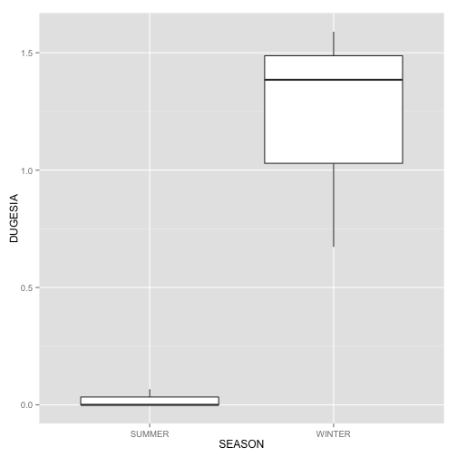

```r
ggplot(curdies.ag, aes(y=DUGESIA,x=SEASON)) + geom_boxplot()
```

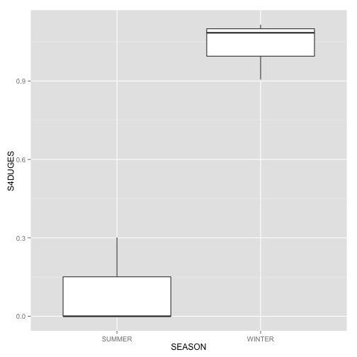

```r
ggplot(curdies.ag, aes(y=S4DUGES,x=SEASON)) + geom_boxplot()
```

Now model using the linear mixed effects model

```r
curdies.lme <- lme(S4DUGES~SEASON,random=~1|SITE, data=curdies)
```

Main effect is SEASON. By the `random=~1|SITE` part we are accounting for the non-indepence within SITE. It is allowing for random intercept (estimating a seperate mean for each site)

Note that the old function 'lmer' is NOT able to incorporate autocorrelation!

Another option is a random slope model

```r
curdies.lme1 <- lme(S4DUGES~SEASON,random=~SEASON|SITE, data=curdies)
```

This one allows the intercept AND the slope to be random! This means that not only can the sites have different means, also, we are allowing the difference between season to be different between site. What we are interested in is the **overal** difference between season, not the site difference.

What you should do is try to run both versions (random intercept and random slope model) and test which one is better using the AIC.

```r
AIC(curdies.lme,curdies.lme1)
```

```
##              df      AIC
## curdies.lme   4 46.42966
## curdies.lme1  6 50.10884
```

```r
anova(curdies.lme,curdies.lme1)
```

```
##              Model df      AIC     BIC    logLik   Test   L.Ratio p-value
## curdies.lme      1  4 46.42966 52.5351 -19.21483
## curdies.lme1     2  6 50.10884 59.2670 -19.05442 1 vs 2 0.3208206  0.8518
```

Next step is to validate the model.

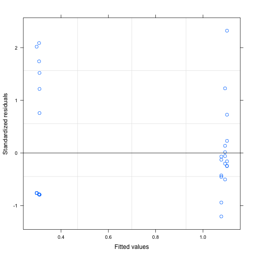

```r
plot(curdies.lme)
```

```r
summary(curdies.lme)
```

```
## Linear mixed-effects model fit by REML
##  Data: curdies
##        AIC     BIC    logLik
##   46.42966 52.5351 -19.21483
##
## Random effects:
##  Formula: ~1 | SITE
##         (Intercept)  Residual
## StdDev:  0.04008595 0.3896804
##
## Fixed effects: S4DUGES ~ SEASON
##                  Value  Std.Error DF  t-value p-value
## (Intercept)  0.3041353 0.09471949 30 3.210905  0.0031
## SEASONWINTER 0.7867589 0.13395359  4 5.873369  0.0042
##  Correlation:
##              (Intr)
## SEASONWINTER -0.707
##
## Standardized Within-Group Residuals:
##        Min         Q1        Med         Q3        Max
## -1.2064783 -0.7680513 -0.2480589  0.3531126  2.3209353
##
## Number of Observations: 36
## Number of Groups: 6
```

`StdDev: 0.04008595 0.3896804`, here `0.04008595` is the variability between sites, and `0.3896804` is the variability between logs. Intercept here is the **average** intercept (which is the summer mean as being alphabetically first). SEASONWINTER -0.707 is the correlation between the slopes of the intercepts. In continuous data we can solve this by centering the data, but this is not possible for a categorical dataset like this one.

```r
anova(curdies.lme)
```

```
##             numDF denDF   F-value p-value
## (Intercept)     1    30 108.45712  <.0001
## SEASON          1     4  34.49647  0.0042
```

We *don't* know what amount degrees of freedom we can use in this test. For this reason, the p-values in this test **don't mean anything!**. A smaller p-value only means that we have used a larger sample size. What we want to know is if there is an effect and the magnitude of that effect.

```r
intervals(curdies.lme)
```

```
## Approximate 95% confidence intervals
##
##  Fixed effects:
##                  lower      est.     upper
## (Intercept)  0.1106923 0.3041353 0.4975783
## SEASONWINTER 0.4148441 0.7867589 1.1586737
## attr(,"label")
## [1] "Fixed effects:"
##
##  Random Effects:
##   Level: SITE
##                        lower       est.    upper
## sd((Intercept)) 1.879311e-07 0.04008595 8550.386
##
##  Within-group standard error:
##     lower      est.     upper
## 0.3025657 0.3896804 0.5018771
```

```r
VarCorr(curdies.lme)
```

```
## SITE = pdLogChol(1)
##             Variance    StdDev
## (Intercept) 0.001606883 0.04008595
## Residual    0.151850778 0.38968035
```

From this table, we can calculate the percentage of variability that is explained by site and small scale:

```r
c(0.04009,0.3897)/sum(c(0.04009,0.3897))
```

```
## [1] 0.09327811 0.90672189
```

So only 10% of the variation in the data is explained by site.

```r
newdata <-data.frame(SEASON=levels(curdies$SEASON))
newdata
```

```
##   SEASON
## 1 SUMMER
## 2 WINTER
```

Now we're asking for the coefficient fixed effects, which we need to repopulation the data

```r
coefs <-fixef(curdies.lme)
```

Now we generate a model matrix for our newdata.

```r
xmat <-model.matrix (~SEASON,data=newdata)
xmat
```

```
##   (Intercept) SEASONWINTER
## 1           1            0
## 2           1            1
## attr(,"assign")
## [1] 0 1
## attr(,"contrasts")
## attr(,"contrasts")$SEASON
## [1] "contr.treatment"
```

Now we can estimate the predicted values.

```r
fit <-t(coefs %*% t(xmat))
fit
```

```
##        [,1]
## 1 0.3041353
## 2 1.0908942
```

However, this doesn't give use the standard errors. We get them as follows:

```r
SE <- sqrt(diag(xmat %*% vcov(curdies.lme) %*% t(xmat)))
```

Finally, we want to turn these standarn errors into confidence intervals

```r
ci <-qt(0.975,length(curdies$SEASON)-2)*SE
newdata<-cbind(newdata,data.frame(fit=fit, se=SE, lower=fit-ci,upper=fit+ci))
head(newdata)
```

```
##   SEASON       fit         se     lower     upper
## 1 SUMMER 0.3041353 0.09471949 0.1116421 0.4966285
## 2 WINTER 1.0908942 0.09471949 0.8984010 1.2833874
```

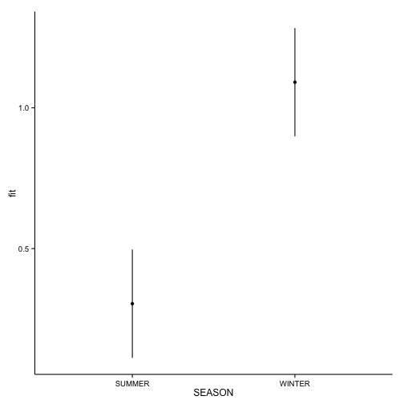

```r
ggplot(newdata,aes(y=fit,x=SEASON)) + geom_point() +
  geom_errorbar(aes(ymin=lower,ymax=upper),width=0)+
  theme_classic()
```

**Randomized block and repeated measures designs**

```r
tobacco <- read.csv('tobacco.csv',strip.white=T)
head(tobacco)
```

```
##   LEAF TREATMENT   NUMBER
## 1   L1    Strong 35.89776
## 2   L1      Weak 25.01984
## 3   L2    Strong 34.11786
## 4   L2      Weak 23.16740
## 5   L3    Strong 35.70215
## 6   L3      Weak 24.12191
```

First step is to explore the assumptions of normality and equal variance. Here we don't need to do aggregations, as the treatments are the actual replicates (not nested)

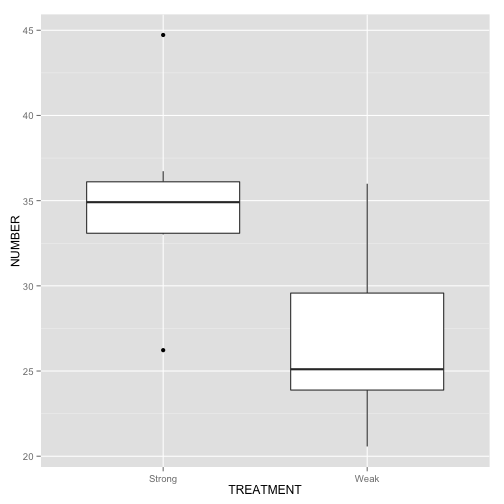

```r
ggplot(tobacco, aes(y=NUMBER,x=TREATMENT)) + geom_boxplot()
```

We do have outliers, but that is because the dataset is smaller (the smaller the dataset, the more outliers). So no problems there, but we do have dependence. So we need to run a model with leaf as a random effect

```r
tobacco.lme <- lme(NUMBER~TREATMENT,random=~1|LEAF,data=tobacco)
tobacco.lme1 <- lme(NUMBER~TREATMENT,random=~TREATMENT|LEAF,data=tobacco)
AICc(tobacco.lme,tobacco.lme1)
```

```
##              df     AICc
## tobacco.lme   4 100.3444
## tobacco.lme1  6 110.0038
```

```r
anova(tobacco.lme,tobacco.lme1)
```

```
##              Model df       AIC       BIC    logLik   Test    L.Ratio
## tobacco.lme      1  4  96.70799  99.26422 -44.35400
## tobacco.lme1     2  6 100.67049 104.50484 -44.33525 1 vs 2 0.03749921
##              p-value
## tobacco.lme
## tobacco.lme1  0.9814
```

So the first model is the best one, so no need to include a random slope.

Next we're going to check for normality and homogeneity of variance by plotting the residuals

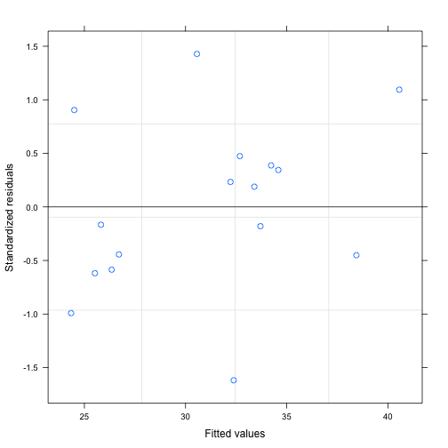

```r
plot(tobacco.lme)
```

Residuals are centered around 0, there is no wedge and no pattern. So that is all fine.

So now we can look at the effect of the model

```r
summary(tobacco.lme)
```

```
## Linear mixed-effects model fit by REML
##  Data: tobacco
##        AIC      BIC  logLik
##   96.70799 99.26422 -44.354
##
## Random effects:
##  Formula: ~1 | LEAF
##         (Intercept) Residual
## StdDev:     3.69221 3.802924
##
## Fixed effects: NUMBER ~ TREATMENT
##                  Value Std.Error DF   t-value p-value
## (Intercept)   34.94013  1.873988  7 18.644800  0.0000
## TREATMENTWeak -7.87938  1.901462  7 -4.143855  0.0043
##  Correlation:
##               (Intr)
## TREATMENTWeak -0.507
##
## Standardized Within-Group Residuals:
##         Min          Q1         Med          Q3         Max
## -1.61850358 -0.48452374  0.01133376  0.40899999  1.42778213
##
## Number of Observations: 16
## Number of Groups: 8
```

`(Intercept) 34.94013 1.873988 7 18.644800 0.0000` shows that 'Strong' has a mean of 34.9, and `TREATMENTWeak -7.87938 1.901462 7 -4.143855 0.0043` shows 'Weak' has a mean of 7.9 less than the average of strong.

Next is split-plot design

```r
copper <- read.csv('copper.csv',strip.white=T)
head(copper)
```

```
##    COPPER PLATE DIST WORMS
## 1 control   200    4 11.50
## 2 control   200    3 13.00
## 3 control   200    2 13.50
## 4 control   200    1 12.00
## 5 control    39    4 17.75
## 6 control    39    3 13.75
```

```r
copper$PLATE <- factor(copper$PLATE)
copper$DIST <- factor(copper$DIST)
```

The interaction of 2 fixed effects must be fixed, the interaction of a fixed and a random effects must be random.

Explore the assumptions of normality and equal variance. We need to aggregate to the level of PLATE

```r
copper.ag <- ddply(copper, ~COPPER+PLATE, numcolwise(mean))
copper.ag
```

```
##     COPPER PLATE   WORMS
## 1  control    34 11.1250
## 2  control    36 11.3125
## 3  control    39 14.1875
## 4  control   179 11.8750
## 5  control   200 12.5000
## 6   Week 1    12  8.9375
## 7   Week 1    21  9.2500
## 8   Week 1    61  7.3125
## 9   Week 1   178  8.2500
## 10  Week 1   199  8.8750
## 11  Week 2    16  3.0625
## 12  Week 2    57  3.0000
## 13  Week 2    63  3.7500
## 14  Week 2   181  3.9375
## 15  Week 2   204  3.1875
```

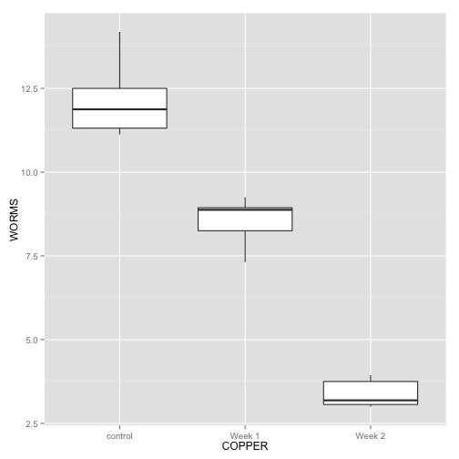

```r
ggplot(copper.ag, aes(y=WORMS,x=COPPER)) + geom_boxplot()
```

There seems to be a small issue with a reduction in the distribution for copper treatments, but we first need to check the interaction between COPPER and DIST. For this we can just use the raw data.

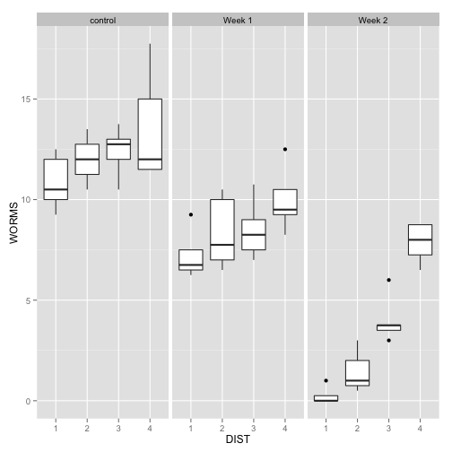

```r
ggplot(copper, aes(y=WORMS,x=DIST)) + geom_boxplot() + facet_wrap(~COPPER)
```

Or

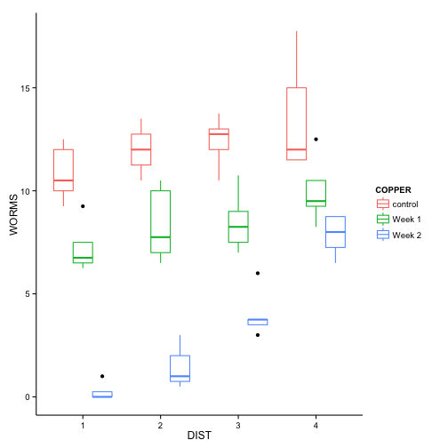

```r
ggplot(copper, aes(y=WORMS,x=DIST,color=COPPER)) + geom_boxplot() +
  theme_classic()
```

Let's look at the data with and without transformation

```r
g1<-ggplot(copper, aes(y=WORMS,x=DIST,color=COPPER)) + geom_boxplot() +
  scale_color_discrete(guide=FALSE) +
  theme_classic()
g2<-ggplot(copper, aes(y=WORMS,x=DIST,color=COPPER)) + geom_boxplot() +
  scale_y_sqrt()+ theme_classic() +
  theme(legend.position=c(1,0),legend.justification=c(1,0))
```

The second plot has a sqrt transformation of the y-axes

Now put multiple panels together

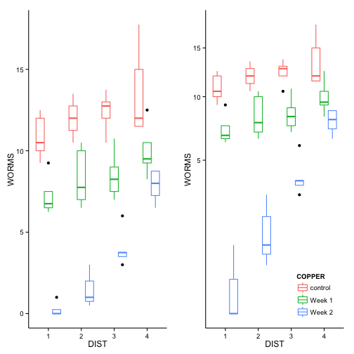

```r
grid.arrange(g1,g2,ncol=2)
```

The transformation doesn't seem to be too much better

Now we need to fit the model

```r
copper.lme<-lme(WORMS~DIST*COPPER, random=~1|PLATE, data=copper)
```

But! We might have to account for correlation structure

```r
copper.lme1<-lme(WORMS~DIST*COPPER, random=~1|PLATE, data=copper,correlation=corCompSymm(form=~1|PLATE))
```

`=corCompSymm(form=~1|PLATE))` specifies that we want a separate corralation structure per plate

We can achieve the same by updating the first model

```r
copper.lme1<-update(copper.lme, correlation=corCompSymm(form=~1|PLATE))
```

Which one is better?

```r
AICc(copper.lme,copper.lme1)
```

```
##             df     AICc
## copper.lme  14 227.5848
## copper.lme1 15 231.1606
```

```r
anova(copper.lme,copper.lme1)
```

```
##             Model df      AIC      BIC    logLik   Test      L.Ratio
## copper.lme      1 14 218.2515 244.4483 -95.12575
## copper.lme1     2 15 220.2515 248.3195 -95.12575 1 vs 2 1.136868e-13
##             p-value
## copper.lme
## copper.lme1       1
```

And test for auto-regressive correlation structure

```r
copper.lme2<-update(copper.lme,
                    correlation=corAR1(form=~1|PLATE))
```

```r
AICc(copper.lme1,copper.lme2)
```

```
##             df     AICc
## copper.lme1 15 231.1606
## copper.lme2 15 225.2792
```

```r
anova(copper.lme1,copper.lme2)
```

```
##             Model df      AIC      BIC    logLik
## copper.lme1     1 15 220.2515 248.3195 -95.12575
## copper.lme2     2 15 214.3701 242.4382 -92.18508
```

**This is why we need to use lme instead of lmer**, because the second one can't adjust for spatial or temporal autocorrelation

Make another column where distance is numeric and not categorical

```r
copper$iDIST<-as.numeric(copper$DIST)
```

Update model

```r
copper.lme2<-update(copper.lme,correlation=corAR1(form=~iDIST|PLATE))
copper.lme2<-update(copper.lme2,method='REML')
```

However, we have not checked if the residuals were correct

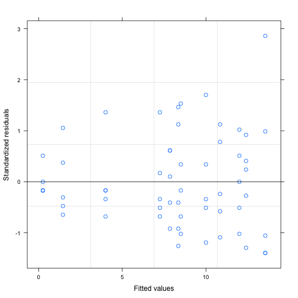

```r
plot(copper.lme2)
```

Again, this is a borderline case.

However, since we are dealing with a complicated structure, we actually need to break the residual plot down into eacht factor

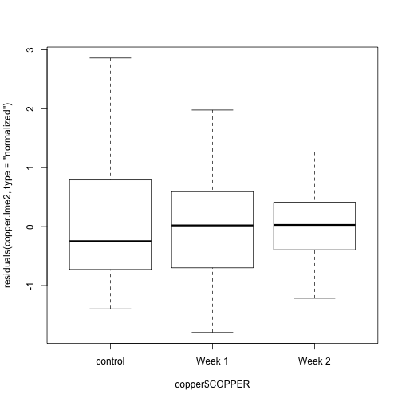

```r
plot(residuals(copper.lme2,type='normalized')~copper$COPPER)
```

We are using the standardized (normalized) residuals, as we accounted for the autocorrelation structure.

We can do the same for distance

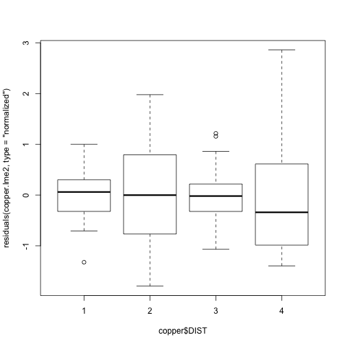

```r
plot(residuals(copper.lme2,type='normalized')~copper$DIST)
```

Now summarize the model

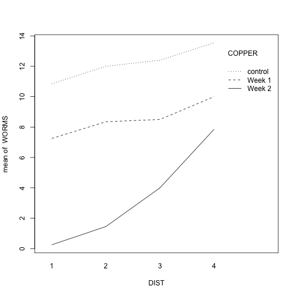

```r
with(copper,interaction.plot(DIST,COPPER,WORMS))
```

```r
summary(copper.lme2)
```

```
## Linear mixed-effects model fit by REML
##  Data: copper
##        AIC      BIC    logLik
##   214.3702 242.4382 -92.18508
##
## Random effects:
##  Formula: ~1 | PLATE
##          (Intercept) Residual
## StdDev: 0.0001127302 1.468741
##
## Correlation Structure: ARMA(1,0)
##  Formula: ~iDIST | PLATE
##  Parameter estimate(s):
##      Phi1
## 0.4479824
## Fixed effects: WORMS ~ DIST * COPPER
##                     Value Std.Error DF    t-value p-value
## (Intercept)         10.85 0.6568410 36  16.518456  0.0000
## DIST2                1.15 0.6901631 36   1.666273  0.1043
## DIST3                1.55 0.8304880 36   1.866372  0.0702
## DIST4                2.70 0.8861734 36   3.046808  0.0043
## COPPERWeek 1        -3.60 0.9289135 12  -3.875495  0.0022
## COPPERWeek 2       -10.60 0.9289135 12 -11.411181  0.0000
## DIST2:COPPERWeek 1  -0.05 0.9760380 36  -0.051228  0.9594
## DIST3:COPPERWeek 1  -0.30 1.1744874 36  -0.255431  0.7998
## DIST4:COPPERWeek 1   0.05 1.2532384 36   0.039897  0.9684
## DIST2:COPPERWeek 2   0.05 0.9760380 36   0.051228  0.9594
## DIST3:COPPERWeek 2   2.20 1.1744874 36   1.873158  0.0692
## DIST4:COPPERWeek 2   4.90 1.2532384 36   3.909871  0.0004
##  Correlation:
##                    (Intr) DIST2  DIST3  DIST4  COPPE1 COPPE2 DIST21 DIST31
## DIST2              -0.525
## DIST3              -0.632  0.602
## DIST4              -0.675  0.468  0.678
## COPPERWeek 1       -0.707  0.371  0.447  0.477
## COPPERWeek 2       -0.707  0.371  0.447  0.477  0.500
## DIST2:COPPERWeek 1  0.371 -0.707 -0.425 -0.331 -0.525 -0.263
## DIST3:COPPERWeek 1  0.447 -0.425 -0.707 -0.480 -0.632 -0.316  0.602
## DIST4:COPPERWeek 1  0.477 -0.331 -0.480 -0.707 -0.675 -0.337  0.468  0.678
## DIST2:COPPERWeek 2  0.371 -0.707 -0.425 -0.331 -0.263 -0.525  0.500  0.301
## DIST3:COPPERWeek 2  0.447 -0.425 -0.707 -0.480 -0.316 -0.632  0.301  0.500
## DIST4:COPPERWeek 2  0.477 -0.331 -0.480 -0.707 -0.337 -0.675  0.234  0.339
##                    DIST41 DIST22 DIST32
## DIST2
## DIST3
## DIST4
## COPPERWeek 1
## COPPERWeek 2
## DIST2:COPPERWeek 1
## DIST3:COPPERWeek 1
## DIST4:COPPERWeek 1
## DIST2:COPPERWeek 2  0.234
## DIST3:COPPERWeek 2  0.339  0.602
## DIST4:COPPERWeek 2  0.500  0.468  0.678
##
## Standardized Within-Group Residuals:
##        Min         Q1        Med         Q3        Max
## -1.3957530 -0.5957482 -0.1702138  0.5361734  2.8595916
##
## Number of Observations: 60
## Number of Groups: 15
```

The degree of correlation between distance 1 and 2 is

```
Phi1
0.4479824
```

There is some evidence about the interaction between distance and copper, so we cannot make any statements about a distance effect and a copper effect.

To explore this further, we can split up the dataset. To do this, we will use degrees of freedom. Better is to name specific contrasts within the analysis we just run

Rerun model

```r
copper.lme2 <- lme(WORMS~COPPER*DIST,random=~1|PLATE,data=copper,
  correlation=corAR1(form=~1|PLATE), method='REML')
```

```r
contrast(copper.lme2,
        a = list(COPPER = "control",DIST = levels(copper$DIST)),
        b = list(COPPER = "Week 1",DIST = levels(copper$DIST)))
```

```
## lme model parameter contrast
##
##  Contrast      S.E.    Lower    Upper    t df Pr(>|t|)
##      3.60 0.9289135 1.729072 5.470928 3.88 45    3e-04
##      3.65 0.9289135 1.779072 5.520928 3.93 45    3e-04
##      3.90 0.9289135 2.029072 5.770928 4.20 45    1e-04
##      3.55 0.9289135 1.679072 5.420928 3.82 45    4e-04
```

Look at control to Week 2

```r
contrast(copper.lme2,
        a = list(COPPER = "control",DIST = levels(copper$DIST)),
        b = list(COPPER = "Week 2",DIST = levels(copper$DIST)))
```

```
## lme model parameter contrast
##
##  Contrast      S.E.    Lower     Upper     t df Pr(>|t|)
##     10.60 0.9289135 8.729072 12.470928 11.41 45        0
##     10.55 0.9289135 8.679072 12.420928 11.36 45        0
##      8.40 0.9289135 6.529072 10.270928  9.04 45        0
##      5.70 0.9289135 3.829072  7.570928  6.14 45        0
```

Look at Week1 to Week 2

```r
contrast(copper.lme2,
        a = list(COPPER = "Week 1",DIST = levels(copper$DIST)),
        b = list(COPPER = "Week 2",DIST = levels(copper$DIST)))
```

```
## lme model parameter contrast
##
##  Contrast      S.E.     Lower    Upper    t df Pr(>|t|)
##      7.00 0.9289135 5.1290722 8.870928 7.54 45   0.0000
##      6.90 0.9289135 5.0290722 8.770928 7.43 45   0.0000
##      4.50 0.9289135 2.6290722 6.370928 4.84 45   0.0000
##      2.15 0.9289135 0.2790722 4.020928 2.31 45   0.0253
```

We are making too many comparisons now, so we need to make some Post-hoc corrections

```r
summary(glht(copper.lme2,linfct=mcp(COPPER='Tukey')))
```

```
##
##   Simultaneous Tests for General Linear Hypotheses
##
## Multiple Comparisons of Means: Tukey Contrasts
##
##
## Fit: lme.formula(fixed = WORMS ~ COPPER * DIST, data = copper, random = ~1 |
##     PLATE, correlation = corAR1(form = ~1 | PLATE), method = "REML")
##
## Linear Hypotheses:
##                       Estimate Std. Error z value Pr(>|z|)
## Week 1 - control == 0  -3.6000     0.9289  -3.875 0.000297 ***
## Week 2 - control == 0 -10.6000     0.9289 -11.411  < 1e-04 ***
## Week 2 - Week 1 == 0   -7.0000     0.9289  -7.536  < 1e-04 ***
## ---
## Signif. codes:  0 '***' 0.001 '**' 0.01 '*' 0.05 '.' 0.1 ' ' 1
## (Adjusted p values reported -- single-step method)
```

Now produce a prettier interaction plot

First, set up a prediction space

```r
newdata <- expand.grid(COPPER=levels(copper$COPPER),
                       DIST=levels(copper$DIST))
```

Next, we extract from our model the coefficients and calculate our model matrix

```r
coefs <- fixef(copper.lme2)
Xmat <- model.matrix(~COPPER*DIST,data=newdata)
fit <- as.vector(Xmat %*% coefs)
newdata$fit <- fit
head(newdata)
```

```
##    COPPER DIST   fit
## 1 control    1 10.85
## 2  Week 1    1  7.25
## 3  Week 2    1  0.25
## 4 control    2 12.00
## 5  Week 1    2  8.35
## 6  Week 2    2  1.45
```

```r
SE <- sqrt(diag(Xmat %*% vcov(copper.lme2) %*% t(Xmat)))
newdata$lower <- fit-2*SE
newdata$upper <- fit+2*SE
head(newdata)
```

```
##    COPPER DIST   fit      lower     upper
## 1 control    1 10.85  9.5363179 12.163682
## 2  Week 1    1  7.25  5.9363179  8.563682
## 3  Week 2    1  0.25 -1.0636821  1.563682
## 4 control    2 12.00 10.6863179 13.313682
## 5  Week 1    2  8.35  7.0363179  9.663682
## 6  Week 2    2  1.45  0.1363179  2.763682
```

There is a negative confidence interval for the 3rd line. This should not be possible. We can fix this by for example do a Poisson or negative binomial

And plot

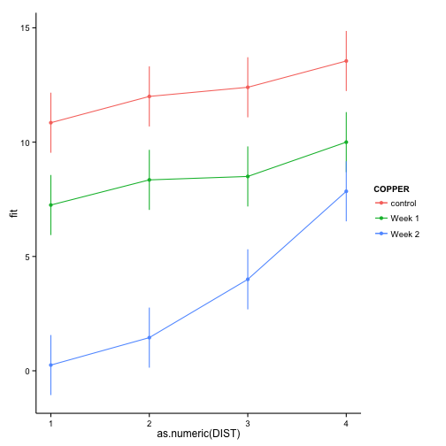

```r
ggplot(newdata,aes(y=fit,x=as.numeric(DIST),color=COPPER))+
  geom_errorbar(aes(ymin=lower,ymax=upper), width=0) +
  geom_point() + geom_line() +
  theme_classic()
```

Or make it even prettier

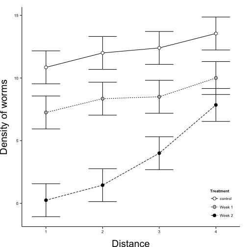

```r
ggplot(newdata,aes(y=fit,x=as.numeric(DIST))) +
  geom_errorbar(aes(ymin=lower,ymax=upper), width=0.5) +
  geom_line(aes(linetype=COPPER))+
  geom_point(aes(shape=COPPER,fill=COPPER),size=3) +
  scale_fill_manual('Treatment',values=c('white','gray','black')) +
  scale_shape_manual('Treatment',values=c(21,21,21)) +
  scale_linetype_discrete('Treatment') +
  scale_y_continuous('Density of worms')+
  scale_x_continuous('Distance')+
  theme_classic() +
  theme(
    text=element_text(size=10),
    axis.title.y=element_text(vjust=2,size=rel(2)),
    axis.title.x=element_text(vjust=-1,size=rel(2)),
    legend.position=c(1,0), legend.justification=c(1,0)
  )
```

**Generalized Linear Models**

The presence-absence of lizards can be modelled to the shape of the island.

```r
polis <- read.csv('polis.csv',strip.white=T)
head(polis)
```

```
##       ISLAND RATIO PA
## 1       Bota 15.41  1
## 2     Cabeza  5.63  1
## 3    Cerraja 25.92  1
## 4 Coronadito 15.17  0
## 5     Flecha 13.04  1
## 6   Gemelose 18.85  0
```

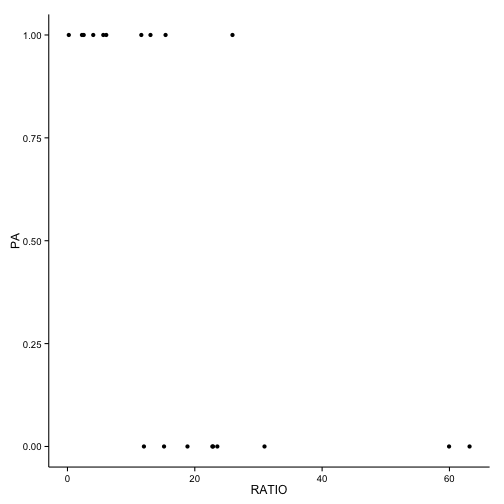

```r
ggplot(polis,aes(y=PA, x=RATIO)) +
  geom_point() +
  theme_classic()
```

This is binomial data, so we're going to assume the data follows a binomial distribution. Make a pretty plot

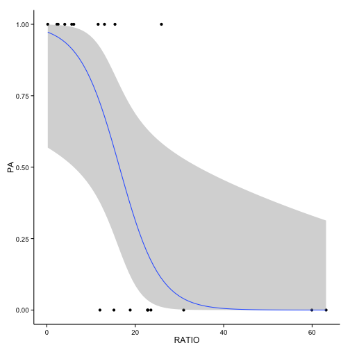

```r
ggplot(polis,aes(y=PA, x=RATIO)) +
  geom_point() +
  geom_smooth(method='glm',formula=y~x, family='binomial') +
  theme_classic()
```

Now let's put it in a model

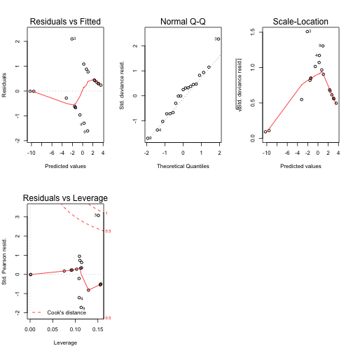

```r
polis.glm <- glm(PA~RATIO, family=binomial(link='logit'), data = polis)
par(mfrow=c(2,3))
plot(polis.glm)
```

Not perfect but 'Eh', this is a small dataset

Now we need to make sure to check that the model fits the data well.

Option1: compare residuals to the residual df. This is the residual sum of squares Option2: getting p-value

```r
polis.resid <-sum(resid(polis.glm,type='pearson')^2)
1-pchisq(polis.resid,polis.glm$df.resid)  #higher than 0.05, so no lack of fit
```

```
## [1] 0.5715331
```

```r
1-pchisq(polis.glm$deviance,polis.glm$df.resid) #Idem
```

```
## [1] 0.6514215
```

Some people prefer a ratio deviance (closer to 1 is better)

```r
polis.glm$deviance/polis.glm$df.resid
```

```
## [1] 0.8365126
```

So our model is good, yay! Now we can summarize it.

```r
summary(polis.glm)
```

```
##
## Call:
## glm(formula = PA ~ RATIO, family = binomial(link = "logit"),
##     data = polis)
##
## Deviance Residuals:
##     Min       1Q   Median       3Q      Max
## -1.6067  -0.6382   0.2368   0.4332   2.0986
##
## Coefficients:
##             Estimate Std. Error z value Pr(>|z|)
## (Intercept)   3.6061     1.6953   2.127   0.0334 *
## RATIO        -0.2196     0.1005  -2.184   0.0289 *
## ---
## Signif. codes:  0 '***' 0.001 '**' 0.01 '*' 0.05 '.' 0.1 ' ' 1
##
## (Dispersion parameter for binomial family taken to be 1)
##
##     Null deviance: 26.287  on 18  degrees of freedom
## Residual deviance: 14.221  on 17  degrees of freedom
## AIC: 18.221
##
## Number of Fisher Scoring iterations: 6
```

These terms however don't relate to a simple intercept or slope, as they are on a logit scale. So we need to do other things, like calculating the R<sup>2:</sup>

```r
1-(polis.glm$deviance/polis.glm$null)
```

```
## [1] 0.4590197
```

We also want to know at which point the switch occurs from likely to be present to likely to be absent (the LD50):

```r
-polis.glm$coef[1]/polis.glm$coef[2]
```

```
## (Intercept)
##     16.4242
```

If we want to reproduce the curve, we need to predict (which involves one extra step compared to earlier, as we need to do a back-transformation):

```r
xs <- seq(min(polis$RATIO),max(polis$RATIO),len=1000)
ys <- predict(polis.glm,newdata=data.frame(RATIO=xs),
             type='link',se=T)
```

We can also do

```r
head(predict(polis.glm,newdata=data.frame(RATIO=xs),
             type='response',se=T))
```

[output not shown]

[output cut: 751 more lines]

[output not shown]

Which will project the data back to the original data, but we don't want it to do that yet as we want to calculate the confidence intervals, for which we need the transformed data

```r
ys$lwr <- polis.glm$family$linkinv(ys$fit - 2*ys$se.fit)
ys$upr <- polis.glm$family$linkinv(ys$fit + 2*ys$se.fit)
ys$fit <- polis.glm$family$linkinv(ys$fit)
newdata <- data.frame(RATIO=xs, fit=ys$fit, lower=ys$lwr, upper=ys$upr)
head(newdata)
```

```
##       RATIO       fit     lower     upper
## 1 0.2100000 0.9723466 0.5518734 0.9990049
## 2 0.2730130 0.9719721 0.5513268 0.9989793
## 3 0.3360260 0.9715927 0.5507782 0.9989530
## 4 0.3990390 0.9712084 0.5502276 0.9989260
## 5 0.4620521 0.9708190 0.5496749 0.9988984
## 6 0.5250651 0.9704245 0.5491202 0.9988701
```

Awesome! Now it is time to plooooot (pretty, please)

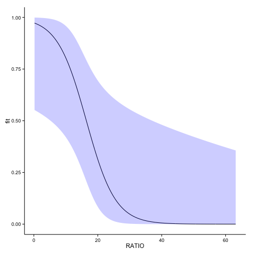

```r
ggplot(newdata,aes(y=fit, x=RATIO)) +
  geom_line() +
  geom_ribbon(aes(ymin=lower,ymax=upper), fill='blue', alpha=.2) +
  theme_classic()
```

Ass this is a model with a single predictor, we could just put the raw data in there, such as

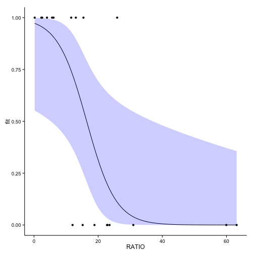

```r
ggplot(newdata,aes(y=fit, x=RATIO)) +
  geom_line() +
  geom_ribbon(aes(ymin=lower,ymax=upper), fill='blue', alpha=.2) +
  geom_point(data=polis,aes(y=PA,x=RATIO)) +
  theme_classic()
```

**Poisson regression**

The closer a poisson distribution is to 0, the more skewed it becomes. The further away from 0, the more it starts resembling a Gaussian. The problem start if the mean is less then 5. In a Poisson, we assume mean = variance. This ratio should be 1. However, a lot of data is over-dispersed, which means that this ratio >1. This can be caused by a lot of factors. A likely scenario is that the data is more variable then you expect based on your model. A second posibility is clumpiness in the data, which is stochastic difference between observations. Another source is an over-representation of zero's in the data. -higher-than-expected variation (solved with *quasi-poisson*, *negative binomial*, or adding an *observation level random effect*, which will 'soak-up' the excess variability) -clumpiness (solved with quasi-poisson) -zero-inflation (solved with zero-inflated poisson)

```r
pois<-read.csv('data.pois.csv', strip.white=T)
head(pois)
```

```
##   y        x
## 1 1 1.024733
## 2 2 2.696719
## 3 3 3.626263
## 4 2 4.948643
## 5 4 6.024718
## 6 8 6.254113
```

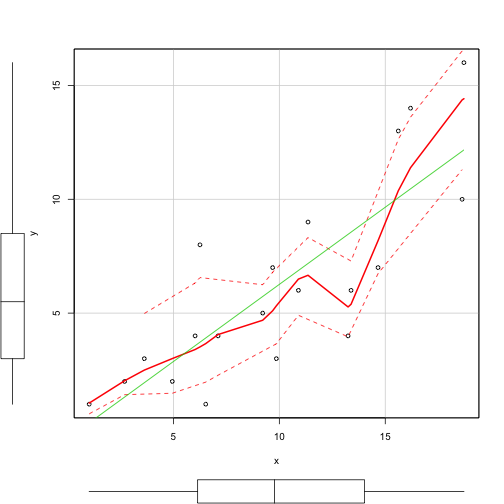

```r
scatterplot(y~x, data=pois)
```

There is potential non-normality of the y variable. Instead of doing a transformation, let's model it as a Poisson, as this is count data. Good practise is to count the number of zero's and the number we're expecting to get

```r
pois.tab <-table(pois$y==0)
pois.tab
```

```
##
## FALSE
##    20
```

So there are no zero's in this data

Now we're going to express it as a percentage (0%). We want to know what proportion of the dataset should be zero. So how many do we expect to get? Get the mean first.

```r
mu <-mean(pois$y)
mu
```

```
## [1] 6.25
```

How many zero's do we expect from a Poisson distribution with mu = 6.25? We can generate data:

```r
cnts <-rpois(1000,mu)
pois.tab <- table(cnts==0)
pois.tab/sum(pois.tab)
```

```
##
## FALSE  TRUE
## 0.999 0.001
```

So let's now fit a model with a Poisson distribution

```r
pois.glm <- glm(y~x, data=pois, family='poisson')
pois.glm <- glm(y~x, data=pois, family=poisson(link='log'))
```

Now look at the residuals

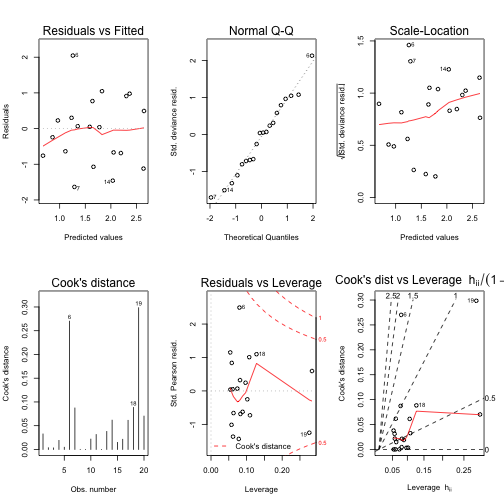

```r
par(mfrow=c(2,3))
plot(pois.glm,ask=F,which=1:6)
```

```r
pois.resid <- sum(resid(pois.glm, type='pearson')^2)
1-pchisq(pois.resid,pois.glm$df.resid)
```

```
## [1] 0.4896553
```

```r
1-pchisq(pois.glm$deviance,pois.glm$df.resid)
```

```
## [1] 0.5076357
```

```r
pois.resid/pois.glm$df.resid
```

```
## [1] 0.9716981
```

```r
pois.glm$deviance/pois.glm$df.resid
```

```
## [1] 0.9569887
```

Great! But now, how do we know it was even worth doing a Poisson? Fit a standard Gaussian and comparing the fits

```r
pois.glmG <- glm(y~x, data=pois,family='gaussian')
AICc(pois.glm,pois.glmG)
```

```
##           df     AICc
## pois.glm   2 91.02482
## pois.glmG  3 99.77600
```

Yes, it was necessary

```r
summary(pois.glm)
```

```
##
## Call:
## glm(formula = y ~ x, family = poisson(link = "log"), data = pois)
##
## Deviance Residuals:
##     Min       1Q   Median       3Q      Max
## -1.6353  -0.7049   0.0440   0.5624   2.0457
##
## Coefficients:
##             Estimate Std. Error z value Pr(>|z|)
## (Intercept)  0.56002    0.25395   2.205   0.0274 *
## x            0.11151    0.01858   6.000 1.97e-09 ***
## ---
## Signif. codes:  0 '***' 0.001 '**' 0.01 '*' 0.05 '.' 0.1 ' ' 1
##
## (Dispersion parameter for poisson family taken to be 1)
##
##     Null deviance: 55.614  on 19  degrees of freedom
## Residual deviance: 17.226  on 18  degrees of freedom
## AIC: 90.319
##
## Number of Fisher Scoring iterations: 4
```

Get the confidence intervals

```r
confint(pois.glm)
```

```
##                  2.5 %    97.5 %
## (Intercept) 0.04158778 1.0384240
## x           0.07556104 0.1485173
```

OR

```r
ci(pois.glm)
```

```
##              Estimate   CI lower  CI upper Std. Error      p-value
## (Intercept) 0.5600204 0.02649343 1.0935474 0.25394898 2.743671e-02
## x           0.1115114 0.07246668 0.1505562 0.01858457 1.970579e-09
```

Upper CI is `exp(0.1115114 + 2*0.01858457)`which is not the same as `exp(0.1505562)`

R<sup>2</sup> is:

```r
1-(pois.glm$deviance/pois.glm$null)
```

```
## [1] 0.6902629
```

Next one, quasi-poisson

```r
data.qp<-read.csv('data.qp.csv', strip.white=T)
head(data.qp)
```

```
##   y        x
## 1 0 1.024733
## 2 3 2.696719
## 3 0 3.626263
## 4 5 4.948643
## 5 6 6.024718
## 6 1 6.254113
```

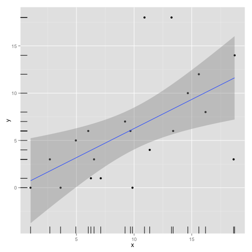

```r
ggplot(data.qp,aes(y=y,x=x)) +
  geom_point() +
  geom_rug() +
  geom_smooth(method='lm')
```

With `geom_rug()` we can identify clumpiness

```r
data.qp.tab<-table(data.qp$y==0)
data.qp.tab/sum(data.qp.tab)
```

```
##
## FALSE  TRUE
##  0.85  0.15
```

```r
mu <- mean(data.qp$y)
cnts <- rpois(1000,mu)
data.qp.tab <- table(cnts == 0)
data.qp.tab/sum(data.qp.tab)
```

```
##
## FALSE  TRUE
## 0.995 0.005
```

So it is *possible* the data is over-dispersed, because there are a lot of zero's. We will fit a Poisson, so we have something to compare to, and fit also a quasi-poisson

```r
data.qp.glm <- glm(y~x, data= data.qp, family='poisson')
data.qp.glm2 <- glm(y~x, data= data.qp, family='quasipoisson')
AICc(data.qp.glm,data.qp.glm2)
```

```
##              df     AICc
## data.qp.glm   2 135.5907
## data.qp.glm2  2       NA
```

NOTE: we cannot calculate the AIC from a quasi-poison. So the only option is to use the likely-ratio test.

```r
anova(data.qp.glm,data.qp.glm2)
```

```
## Analysis of Deviance Table
##
## Model 1: y ~ x
## Model 2: y ~ x
##   Resid. Df Resid. Dev Df Deviance
## 1        18     69.987
## 2        18     69.987  0        0
```

A quasi-poisson will estimate the mean first, and then go back and estimate the variance. For this reason the confidence intervals will be different for both models.

```r
summary(data.qp.glm2)
```

```
##
## Call:
## glm(formula = y ~ x, family = "quasipoisson", data = data.qp)
##
## Deviance Residuals:
##     Min       1Q   Median       3Q      Max
## -3.3665  -1.7360  -0.1239   0.7436   3.9335
##
## Coefficients:
##             Estimate Std. Error t value Pr(>|t|)
## (Intercept)   0.6996     0.4746   1.474   0.1577
## x             0.1005     0.0353   2.846   0.0107 *
## ---
## Signif. codes:  0 '***' 0.001 '**' 0.01 '*' 0.05 '.' 0.1 ' ' 1
##
## (Dispersion parameter for quasipoisson family taken to be 3.698815)
##
##     Null deviance: 101.521  on 19  degrees of freedom
## Residual deviance:  69.987  on 18  degrees of freedom
## AIC: NA
##
## Number of Fisher Scoring iterations: 5
```

The over-dispersion parameter is greater than 2 (which we use as a cut-off value), so we conclude there is overdispersion.

Another option is to use a negative binomal, which is:

```r
data.qp.nb <-glm.nb(y~x, data=data.qp)
```

Get the theta

```r
data.qp.nb$theta
```

```
## [1] 2.221211
```

This is not the exact same as the dispersion parameter, but we use it in the same way.

```r
summary(data.qp.nb)
```

```
##
## Call:
## glm.nb(formula = y ~ x, data = data.qp, init.theta = 2.221210756,
##     link = log)
##
## Deviance Residuals:
##     Min       1Q   Median       3Q      Max
## -2.3182  -1.0703  -0.1635   0.4198   1.7886
##
## Coefficients:
##             Estimate Std. Error z value Pr(>|z|)
## (Intercept)  0.41366    0.43526   0.950 0.341917
## x            0.12575    0.03625   3.469 0.000523 ***
## ---
## Signif. codes:  0 '***' 0.001 '**' 0.01 '*' 0.05 '.' 0.1 ' ' 1
##
## (Dispersion parameter for Negative Binomial(2.2212) family taken to be 1)
##
##     Null deviance: 34.058  on 19  degrees of freedom
## Residual deviance: 23.709  on 18  degrees of freedom
## AIC: 113.84
##
## Number of Fisher Scoring iterations: 1
##
##
##               Theta:  2.22
##           Std. Err.:  1.09
##
##  2 x log-likelihood:  -107.837
```

We can use a nb for clumpiness or with zero-inflated data (up to 20% zero's)

```r
data.qp.glm3<-glm(y~x,data=data.qp,family=negative.binomial(theta=2.2))
```

For this we need to know the theta though, so this method is less useful than the previous one

Let's spend more time on zero-inflated models. There can be 2 reasons: -there is nothing to observe (can be modelled with Poisson) -the observation is missed

```r
data.zip <- read.csv('data.zip.csv',strip.white=T)
head(data.zip)
```

```
##   y        x
## 1 0 1.042191
## 2 3 2.497906
## 3 1 3.676603
## 4 4 3.798047
## 5 5 4.870992
## 6 1 7.689958
```

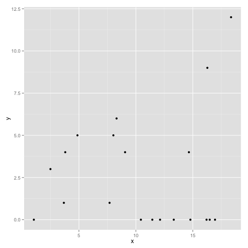

```r
ggplot(data.zip,aes(y=y,x=x)) + geom_point()
```

What we observed and expected

```r
mu <- mean(data.zip$y)
cnts<-rpois(1000,mu)
data.zip.tab <-table(cnts == 0)
data.zip.tab/sum(data.zip.tab)
```

```
##
## FALSE  TRUE
## 0.923 0.077
```

Only handle the fact I have excess zero's

```r
data.zip.zip <- zeroinfl(y~x | 1, dist = "poisson", data = data.zip)
```

Or model the excess zero's as well, and see if there is a pattern

```r
data.zip.zip1 <- zeroinfl(y~x | x, dist = "poisson", data = data.zip)
```

```r
summary(data.zip.zip)
```

```
##
## Call:
## zeroinfl(formula = y ~ x | 1, data = data.zip, dist = "poisson")
##
## Pearson residuals:
##     Min      1Q  Median      3Q     Max
## -1.0015 -0.9556 -0.3932  0.9663  1.6195
##
## Count model coefficients (poisson with log link):
##             Estimate Std. Error z value Pr(>|z|)
## (Intercept)  0.70474    0.31960   2.205 0.027449 *
## x            0.08734    0.02532   3.449 0.000563 ***
##
## Zero-inflation model coefficients (binomial with logit link):
##             Estimate Std. Error z value Pr(>|z|)
## (Intercept)  -0.2292     0.4563  -0.502    0.615
## ---
## Signif. codes:  0 '***' 0.001 '**' 0.01 '*' 0.05 '.' 0.1 ' ' 1
##
## Number of iterations in BFGS optimization: 13
## Log-likelihood: -36.17 on 3 Df
```

```r
summary(data.zip.zip1)
```

```
##
## Call:
## zeroinfl(formula = y ~ x | x, data = data.zip, dist = "poisson")
##
## Pearson residuals:
##     Min      1Q  Median      3Q     Max
## -1.2761 -0.7814 -0.5933  0.9078  2.1317
##
## Count model coefficients (poisson with log link):
##             Estimate Std. Error z value Pr(>|z|)
## (Intercept)  0.61113    0.33001   1.852 0.064044 .
## x            0.09389    0.02574   3.647 0.000265 ***
##
## Zero-inflation model coefficients (binomial with logit link):
##             Estimate Std. Error z value Pr(>|z|)
## (Intercept)  -2.7305     1.8897  -1.445    0.148
## x             0.2170     0.1461   1.485    0.137
## ---
## Signif. codes:  0 '***' 0.001 '**' 0.01 '*' 0.05 '.' 0.1 ' ' 1
##
## Number of iterations in BFGS optimization: 17
## Log-likelihood: -34.41 on 4 Df
```

To see if there is a pattern in the data, look at this part: 'Zero-inflation model coefficients (binomial with logit link)' In this case there is no pattern

Which models the data better?

```r
AICc(data.zip.zip,data.zip.zip1)
```

```
##               df     AICc
## data.zip.zip   3 79.84277
## data.zip.zip1  4 79.47724
```

# Day 3 - Bayesian

With frequentist it is almost impossible *not* to disprove the null-hypothesis, as the probability of the data is calculated from the data. We are not interested in the sample, we are interested in the population.

```
                   *Frequentist*       *Bayesian*
Observed data     One possible          Fixed, true
Parameters        Fixed, true           Random, distribution
Inferences        Data                  Parameters
Probability       Long-run frequence    Degree of belief
                    $(P|H)$               $P(H|D)$
```

With the Frequentist approach you get one point value for the slope, with the Bayesian you get a distribution. When 90% of this distribution lies above or below zero, you can consider that there is an effect in the data.

*Bayes rule*

*P*(*H*|*D*) = (*P*(*D*|*H*) * P(*H*)) / *P*(*D*)

posterior probability = ( likelyhood x prior probability) / normalizing constant

Propability distribution: area under curve must be 1 Likelihood distribution: are under curve is unknown

Above formula normalizes the area under the curve and makes it equal to 1

**Bayesian is robust to:**

> unequal sample sizes

> balance

> collinearity

> pair-wise comparisons (no need for *post-hoc* tests)

**MCMC-Sampling**

Random walks on distribution. Will always accept a position with a higher probability and whether or not a lower probability point is accepted depends on the actual likelihood of that point. For this reason, we will get a better overview of more probable parts of the distribution. This chain of walks is called a chain!

- Run 3 chains to make sure this is the distribution
- Burning: run for example for a 1000 steps (50% of the actual iterations you want to run) and see what an appropriate distance per step is. After this burning, chuck this burning run out.
- Number of iterations: determined by diagnostics that are run

Start with 10000 iterations and make trace plots:

- needs to be total chaos, when not, include more iterations
- needs to be repeatable

Autocorrelation

- ACF plot
- thinning, thinning factor 10 means only sample every 10th point. When thinning, make sure to increase the number of iterations.

Distribution plots

- multiple modes –> not one single population sampled
- highly skewed –> take median or mode
- area under curve is 1
- credibility intervals (same as confidence interval)

MCMCglmm is not too highly developed in R… Alternative is WinBUGS or JAGS (C++). These programs use a Gibbs sampler. This changes one parameter at a time (for example first intercept, then slope). Better samplers exist, one of which is implemented in STAND.

In C++ not everything has to be scripted in the same order, but everything **will be run simultaneously**

JAGS can be run through other platforms requires and 3 inputs:

- file with model statement
- data in the form of a list
- parameters that define the run (number of iterations, burning etc)

From R: R2Jags

Start as simple as possible, get something to compare to

```r
fert <- read.csv('fertilizer.csv',strip.white=T)
summary(lm(YIELD~FERTILIZER,data=fert))
```

```
##
## Call:
## lm(formula = YIELD ~ FERTILIZER, data = fert)
##
## Residuals:
##    Min     1Q Median     3Q    Max
## -22.79 -11.07  -5.00  12.00  29.79
##
## Coefficients:
##             Estimate Std. Error t value Pr(>|t|)
## (Intercept) 51.93333   12.97904   4.001  0.00394 **
## FERTILIZER   0.81139    0.08367   9.697 1.07e-05 ***
## ---
## Signif. codes:  0 '***' 0.001 '**' 0.01 '*' 0.05 '.' 0.1 ' ' 1
##
## Residual standard error: 19 on 8 degrees of freedom
## Multiple R-squared:  0.9216, Adjusted R-squared:  0.9118
## F-statistic: 94.04 on 1 and 8 DF,  p-value: 1.067e-05
```

To get the contents of the package, type `MCMCpack:::`

This package only runs one chain at the time, so it should be run 3 times

```r
fert.mcmc1 <- MCMCregress(YIELD~FERTILIZER, data=fert,
                          burnin = 100, mcmc =1000, thin=1,seed=1)
```

Seed: the random seed, which dictates how the randomization works. So if you want to run another random run, select another seed:

```r
fert.mcmc2 <- MCMCregress(YIELD~FERTILIZER, data=fert,
                          burnin = 100, mcmc =1000, thin=1,seed=2)
fert.mcmc3 <- MCMCregress(YIELD~FERTILIZER, data=fert,
                          burnin = 100, mcmc =1000, thin=1,seed=3)
```

Now merge them together so you have one object which you can process together.

```r
fert.mcmc <-as.mcmc.list(list(fert.mcmc1,fert.mcmc2,fert.mcmc3))
```

Now take advantage of things that are within coda, like the plotting function

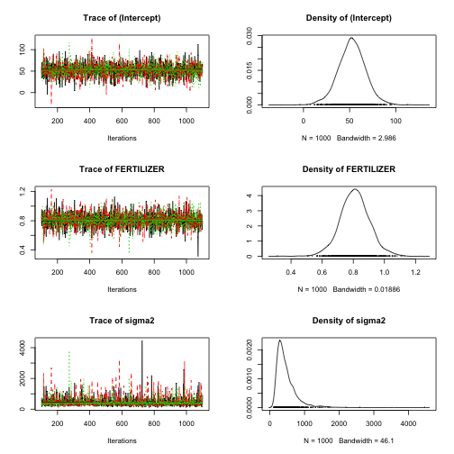

```r
plot(fert.mcmc)
```

> Top row: intercept Middle row: slope Bottom row: variance

Colours of the lines, black, green and red (printed in that order) are the 3 runs. You want these runs to show the exact same. These are, so it's likely you have transfersed the entire prosterior.

Notice that the slope and intercept are fairly normal, so to describe it a mean would be OK. The variance is skewed so to describe it a mode or median would be better.

We used a thinning of 1, which is a lag of one in the next output:

```r
autocorr.diag(fert.mcmc)
```

```
##          (Intercept)   FERTILIZER       sigma2
## Lag 0   1.000000e+00  1.000000000  1.000000000
## Lag 1   2.134962e-02  0.021334473  0.209033144
## Lag 5  -7.698278e-05 -0.011779817 -0.019172034
## Lag 10 -2.021870e-02 -0.030589123 -0.034440715
## Lag 50 -6.545629e-03  0.006366862 -0.003426807
```

We don't want to see high numbers in this plot. A high number is something higher that .2. We have one sigma2 value which is greater than .2, so we have quite a bit of correlation. So we need to re-run the chains with a different thinning factor. Now this output is obvious. Note that sometimes this autocorrelation loops back to higher value.

Let's try a thin of 5 (now need to increase the number of iterations 5 times)

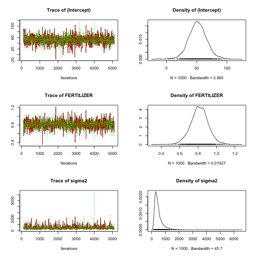

```r
fert.mcmc1 <- MCMCregress(YIELD~FERTILIZER, data=fert,
                          burnin = 100, mcmc =5000, thin=5,seed=2)
fert.mcmc2 <- MCMCregress(YIELD~FERTILIZER, data=fert,
                          burnin = 100, mcmc =5000, thin=5,seed=2)
fert.mcmc3 <- MCMCregress(YIELD~FERTILIZER, data=fert,
                          burnin = 100, mcmc =5000, thin=5,seed=3)
fert.mcmc <-as.mcmc.list(list(fert.mcmc1,fert.mcmc2,fert.mcmc3))
plot(fert.mcmc)
```

```r
autocorr.diag(fert.mcmc)
```

```
##         (Intercept)   FERTILIZER       sigma2
## Lag 0    1.00000000  1.000000000  1.000000000
## Lag 5   -0.01923931 -0.029998359 -0.036489106
## Lag 25  -0.01544306 -0.013277458 -0.022565790
## Lag 50  -0.02206422 -0.024020508 -0.007797309
## Lag 250 -0.01786679 -0.005201497  0.055493338
```

Now all looks good.

There is another diagnostic, the raftery diagnostic. Looks if you had enough samples in your chains

```r
raftery.diag(fert.mcmc)
```

```
## [[1]]
##
## Quantile (q) = 0.025
## Accuracy (r) = +/- 0.005
## Probability (s) = 0.95
##
## You need a sample size of at least 3746 with these values of q, r and s
##
## [[2]]
##
## Quantile (q) = 0.025
## Accuracy (r) = +/- 0.005
## Probability (s) = 0.95
##
## You need a sample size of at least 3746 with these values of q, r and s
##
## [[3]]
##
## Quantile (q) = 0.025
## Accuracy (r) = +/- 0.005
## Probability (s) = 0.95
##
## You need a sample size of at least 3746 with these values of q, r and s
```

So we need at least 3746 samples in our chains, we had 5000, so yay.

Now summarize the data:

```r
summary(fert.mcmc)
```

```
##
## Iterations = 101:5096
## Thinning interval = 5
## Number of chains = 3
## Sample size per chain = 1000
##
## 1. Empirical mean and standard deviation for each variable,
##    plus standard error of the mean:
##
##                 Mean        SD Naive SE Time-series SE
## (Intercept)  51.6028  15.09567 0.275608       0.275694
## FERTILIZER    0.8136   0.09741 0.001778       0.001779
## sigma2      481.4807 326.87948 5.967975       6.082233
##
## 2. Quantiles for each variable:
##
##                 2.5%      25%      50%      75%    97.5%
## (Intercept)  22.6589  42.1738  51.3531  60.7618   83.090
## FERTILIZER    0.6177   0.7533   0.8145   0.8742    1.003
## sigma2      163.6239 280.8889 393.0157 567.4057 1304.868
```

We can now make the statement that the slope is between 0.62 and 1.0 with 95% probability. We CANNOT make the same statement with 95% confidence intervals.

```r
fert.mcmc <- rbind(fert.mcmc1, fert.mcmc2,fert.mcmc3)
head(fert.mcmc)
```

```
##      (Intercept) FERTILIZER   sigma2
## [1,]    55.38547  0.8549987 342.9582
## [2,]    46.22085  0.8643291 232.6710
## [3,]    45.03659  0.9064213 533.8965
## [4,]    91.29923  0.5449321 651.3404
## [5,]    84.76013  0.6310048 460.3705
## [6,]    40.13982  0.8640221 434.3334
```

We now have 3000 estimates of slopes (1000 per run).

We can now make a histogram with the distribution of the slopes.

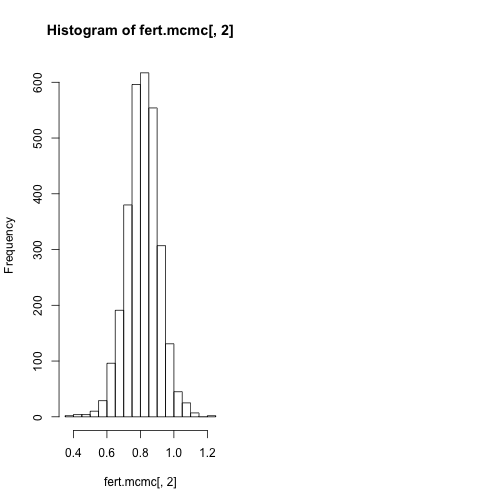

```r
par(mfrow=c(1,2))
hist(fert.mcmc[,2])
```

The estimate of the slope is the mean or the median:

```r
mean(fert.mcmc[,2])
```

```
## [1] 0.8135513
```

And the credibility intervals are:

```r
HPDinterval(as.mcmc(fert.mcmc[,2]))
```

```
##          lower     upper
## var1 0.6134619 0.9973995
## attr(,"Probability")
## [1] 0.95
```

These intervals are density based, and don't have to be equal around the mean.

In library(plyr)

```r
fert.sum <- adply(fert.mcmc,2, function(x) {
  data.frame(Mean=mean(x), Median=median(x),HPDinterval(as.mcmc(x)))
})
```

In this formula, the 2 refers to the columns.

```r
head(fert.sum)
```

```
##            X1        Mean      Median       lower        upper
## 1 (Intercept)  51.6028219  51.3530676  21.9276011   81.0833320
## 2  FERTILIZER   0.8135513   0.8145226   0.6134619    0.9973995
## 3      sigma2 481.4806653 393.0156667 117.0085183 1098.0993029
```

We can now see how many times the estimate of the slope was greater than 0:count up the number of slopes greater than zero and devide this by 3000 (for the total number of iterations):

```r
table(fert.mcmc[,2]>0)
```

```
##
## TRUE
## 3000
```

```r
table(fert.mcmc[,2]>0)/length(fert.mcmc[,2])
```

```
##
## TRUE
##    1
```

We can now also test our distribution agains any hypothesis (e.g. the slope is .8):

```r
table(fert.mcmc[,2]>0.8)
```

```
##
## FALSE  TRUE
##  1312  1688
```

```r
table(fert.mcmc[,2]>0.8)/length(fert.mcmc[,2])
```

```
##
##     FALSE      TRUE
## 0.4373333 0.5626667
```

In JAGS/BUGS, things are written in terms of precision, not variance.

Model: y(i) ~ N(mu(i),tau) mu(i) = beta(0) + beta(1*x(i))

We are going to use some non-informative priors:

> beta(0) ~ *N*(0,0.000001) : the intercept is 0 with a very high uncertaincy beta(1) ~ *N*(0,0.000001) : the slope is 0 with a very high uncertaincy sigma ~ *Uniform*(0,100)

The model is (by using R to write the text file for you)

```r
modelString="
model {
  #Likelihood
  for (i in 1:n) {
    y[i]~dnorm(mu[i],tau)
    mu[i] <- beta0+beta1*x[i]
  }

  #Priors
  beta0 ~dnorm(0,1.0E-6)
  beta1 ~dnorm(0,1.0E-6)
  tau <- 1/ (sigma * sigma)
  sigma~dunif(0,100)
}
"
writeLines(modelString,con="regression.txt")
```

Now we need to create a list with out data in it. The above model is expecting x, y and n (number of rows)

```r
fert.list <- with(fert,
                  list(x=FERTILIZER,
                  y=YIELD,n=nrow(fert))
                  )
```

Now add the parameters

```r
params<- c("beta0","beta1","sigma")
```

Now put it in Jags library(R2Jags) Use the chache=TRUE command in the {r} for knitr, so it stores the data and it doesn't have to re-run every time you run knitter. Do this for any large amounts of data

```r
library("R2jags", lib.loc="/Library/Frameworks/R.framework/Versions/3.0/Resources/library")
fert.r2jags <- jags(data=fert.list,
                    inits=NULL,
                    parameters.to.save=params,
                    model.file="regression.txt",
                    n.chains=3,
                    n.iter=1000,
                    n.burnin=100,
                    n.thin=5
                    )
```

```
## module glm loaded
```

```
##    Graph Size: 50
##
```

In the output, the first line represents the burnin, the second one the iterations. This has now come back from jags and we need to run diagnostics

`quartz()` can be used if figure margins are too large

```r
plot(as.mcmc(fert.r2jags))
```

```
## Error in character(ncol(y)): invalid 'length' argument
```

```r
library("R2jags", lib.loc="/Library/Frameworks/R.framework/Versions/3.0/Resources/library")
fert.r2jags2 <- jags(data=fert.list,
                    inits=NULL,
                    parameters.to.save=params,
                    model.file="regression.txt",
                    n.chains=3,
                    n.iter=10000,
                    n.burnin=1000,
                    n.thin=5
                    )
```

```
##    Graph Size: 50
##
```

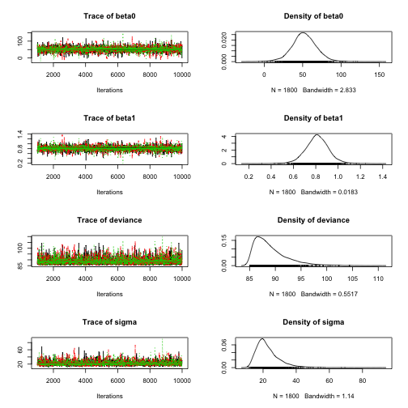

```r
plot(as.mcmc(fert.r2jags2))
```

```r
autocorr.diag(as.mcmc(fert.r2jags2))
```

```
## Error in complete.cases(object): not all arguments have the same length
```

```r
print(fert.r2jags)
```

[output not shown]

[output cut: 3638 more lines]

In this, you want n.eff to be at least half of the number of iterations. Because there is no use of calculating the mean slopes etc when you don't have a high enough number of **effective** estimates.

```r
modelString="
model {
  #Likelihood
  for (i in 1:n) {
    y[i]~dnorm(mu[i],tau)
    mu[i] <- beta0+beta1*x[i]
    y.err[i] <- x[i] - mu[i]
  }

  #Priors
  beta0 ~dnorm(0,1.0E-6)
  beta1 ~dnorm(0,1.0E-6)
  tau <- 1/ (sigma * sigma)
  sigma~dunif(0,100)
  p.increase <- step(beta1)
  sd.x <- abs(beta1)*sd(x[])
  sd.resid <- sd(y.err)
}
"
writeLines(modelString,con="regression2.txt")

fert.list <- with(fert,
                  list(x=FERTILIZER,
                  y=YIELD,n=nrow(fert))
                  )
```

We need to change the parameters, because we want more to be returned to us

```r
params<- c("beta0","beta1","sigma","p.increase","sd.x","sd.resid")
```

```r
burnInSteps = 2000
nChains = 3
numSavedSteps = 50000
thinSteps = 5
nIter = ceiling((numSavedSteps * thinSteps)/nChains)
nIter
```

```
## [1] 83334
```

```r
library("R2jags", lib.loc="/Library/Frameworks/R.framework/Versions/3.0/Resources/library")
fert.r2jags3 <- jags(data=fert.list,
                    inits=NULL,
                    parameters.to.save=params,
                    model.file="regression2.txt",
                    n.chains=nChains,
                    n.iter=nIter,
                    n.burnin=burnInSteps,
                    n.thin=thinSteps
                    )
```

```
##    Graph Size: 67
##
```

```r
#print(fert.r2jags3)
```

Start making some plots. First convert to mcmc output:

```r
fert.mcmc <- as.mcmc(fert.r2jags$BUGSoutput$sims.matrix)
head(fert.mcmc)
```

```
## Markov Chain Monte Carlo (MCMC) output:
## Start = 1
## End = 7
## Thinning interval = 1
##         beta0     beta1 deviance    sigma
## [1,] 53.78310 0.7867868 85.42657 19.04031
## [2,] 53.39818 0.7906458 85.69022 20.26728
## [3,] 54.92076 0.8710892 89.63111 17.75630
## [4,] 48.60204 0.8639909 86.79097 14.81668
## [5,] 74.53742 0.7016324 88.86944 23.38609
## [6,] 51.48092 0.8553789 88.44949 26.06636
## [7,] 49.42679 0.7920673 87.08029 22.97741
```

```r
coefs <- fert.mcmc[,1:2]
xs <- seq(min(fert$FERTILIZER), max(fert$FERTILIZER),len=100)
Xmat <- model.matrix(~FERTILIZER,data=data.frame(FERTILIZER=xs))
head(Xmat)
```

```
##   (Intercept) FERTILIZER
## 1           1   25.00000
## 2           1   27.27273
## 3           1   29.54545
## 4           1   31.81818
## 5           1   34.09091
## 6           1   36.36364
```

```r
pred <- coefs %*% t(Xmat)
dim(pred)
```

```
## [1] 540 100
```

```r
#newdata <- adply(pred,2,function(x){
#  data.frame(Mean=mean(x),Median=median(x),HPDinterval(as.mcmc(x))
#})
#newdata <- cbind(newdata,FERTILIZER=xs)
#head(newdata)
```

```r
#ggplot(newdata,aes(y=Mean,x=FERTILIZER)) + geom_line()
#  geom_ribbon(aes(ymin=lower,ymax=upper),fill='blue', alpha=.2) +
# theme_classic()
```

```r
loyn <- read.csv('loyn.csv',strip.white=T)
head(loyn)
```

```
##   ABUND AREA YR.ISOL DIST LDIST GRAZE ALT
## 1   5.3  0.1    1968   39    39     2 160
## 2   2.0  0.5    1920  234   234     5  60
## 3   1.5  0.5    1900  104   311     5 140
## 4  17.1  1.0    1966   66    66     3 160
## 5  13.8  1.0    1918  246   246     5 140
## 6  14.1  1.0    1965  234   285     3 130
```

```r
loyn$logAREA <- log10(loyn$AREA)
loyn$logDIST <- log10(loyn$DIST)
loyn$logLDIST <- log10(loyn$LDIST)
summary(lm(ABUND~logAREA+logDIST+logLDIST+GRAZE+ALT+YR.ISOL,data=loyn))
```

```
##
## Call:
## lm(formula = ABUND ~ logAREA + logDIST + logLDIST + GRAZE + ALT +
##     YR.ISOL, data = loyn)
##
## Residuals:
##      Min       1Q   Median       3Q      Max
## -15.6506  -2.9390   0.5289   2.5353  15.2842
##
## Coefficients:
##               Estimate Std. Error t value Pr(>|t|)
## (Intercept) -125.69725   91.69228  -1.371   0.1767
## logAREA        7.47023    1.46489   5.099 5.49e-06 ***
## logDIST       -0.90696    2.67572  -0.339   0.7361
## logLDIST      -0.64842    2.12270  -0.305   0.7613
## GRAZE         -1.66774    0.92993  -1.793   0.0791 .
## ALT            0.01951    0.02396   0.814   0.4195
## YR.ISOL        0.07387    0.04520   1.634   0.1086
## ---
## Signif. codes:  0 '***' 0.001 '**' 0.01 '*' 0.05 '.' 0.1 ' ' 1
##
## Residual standard error: 6.384 on 49 degrees of freedom
## Multiple R-squared:  0.6849, Adjusted R-squared:  0.6464
## F-statistic: 17.75 on 6 and 49 DF,  p-value: 8.443e-11
```

```r
modelString="
model {
  #Likelihood
  for (i in 1:n) {
    abund[i]~dnorm(mu[i],tau)
    mu[i] <- beta0+beta.dist*(dist[i])+beta.ldist*(ldist[i]) +
      beta.area*(area[i]) + beta.graze*(graze[i]) +
      beta.alt*(alt[i]) + beta.yr*(yr[i])
    }

  #Priors
  beta0 ~dnorm(0,1.0E-6)
  beta.dist ~dnorm(0,1.0E-6)
  beta.ldist ~dnorm(0,1.0E-6)
  beta.area ~dnorm(0,1.0E-6)
  beta.graze ~dnorm(0,1.0E-6)
  beta.alt ~dnorm(0,1.0E-6)
  beta.yr ~dnorm(0,1.0E-6)
  tau <- 1/ (sigma * sigma)
  sigma~dunif(0,100)
  }
"
writeLines(modelString,con="multregression.txt")

loyn.list <- with(loyn,
                  list(abund=ABUND,dist=logDIST,ldist=logLDIST,area=logAREA,
                       graze=GRAZE,alt=ALT,yr=YR.ISOL,
                       n=nrow(loyn))
                  )
params<- c("beta0","beta.dist","beta.ldist","beta.area","beta.graze",
           "beta.alt","beta.yr","sigma")

burnInSteps = 2000
nChains = 3
numSavedSteps = 50000
thinSteps = 5
nIter = ceiling((numSavedSteps * thinSteps)/nChains)
nIter
```

```
## [1] 83334
```

```r
library("R2jags", lib.loc="/Library/Frameworks/R.framework/Versions/3.0/Resources/library")
loyn.r2jags <- jags(data=loyn.list,
                    inits=NULL,
                    parameters.to.save=params,
                    model.file="multregression.txt",
                    n.chains=nChains,
                    n.iter=nIter,
                    n.burnin=burnInSteps,
                    n.thin=thinSteps
                    )
```

```
##    Graph Size: 626
##
```

There is a shorter way. Instead of having to write out all the beta's, there is a matrix of beta's. This will work for simple regression, multiple regression etc. It is as follows:

```r
modelString="
model {
  for (i in 1:n) {
    y[i]~dnorm(mu[i],tau)
    mu[i] <- inprod(beta[],x[i,])
    y.err[i] <- y[i] - mu[i]
    }
  for (i in 1:nX) {
    beta[i] ~ dnorm(0,1.0E-06)
    }
  tau <- 1/ (sigma*sigma)
  sigma~dunif(0,100)
  }
"
writeLines(modelString,con="multregression1.txt")
```

beta[] works out how many betas you need and makes a matrix of them. Then we can just look through defining our priors for teh betas!

So the data list we supply must have:

- the resonse vector
- a model matrix of the predictor variables (linear predictor)
- N (the number of rows in teh dataset)
- nX, the number of predictors (including the intercept)

Her is the model matrix. The first column contains only ones, the other columns represent the predictor variables

```r
X <- model.matrix(~logDIST+logLDIST+logAREA+GRAZE+ALT+YR.ISOL,data=loyn)
head(X)
```

```
##   (Intercept)  logDIST logLDIST  logAREA GRAZE ALT YR.ISOL
## 1           1 1.591065 1.591065 -1.00000     2 160    1968
## 2           1 2.369216 2.369216 -0.30103     5  60    1920
## 3           1 2.017033 2.492760 -0.30103     5 140    1900
## 4           1 1.819544 1.819544  0.00000     3 160    1966
## 5           1 2.390935 2.390935  0.00000     5 140    1918
## 6           1 2.369216 2.454845  0.00000     3 130    1965
```

Here, X is a matrix!

Now I will count how many columns there are in this model matrix. In this case this is easy - there are seven. But it is useful to have this calculated for use for some circumstances

```r
nX <- ncol(X)
nX
```

```
## [1] 7
```

Now I have to define the parameters and run jags

```r
params<- c("beta","sigma","y.err")
burnInSteps = 2000
nChains = 3
numSavedSteps = 50000
thinSteps = 5
nIter = ceiling((numSavedSteps * thinSteps)/nChains)
nIter
```

```
## [1] 83334
```

```r
loyn.list <- with(loyn,list(y=ABUND, x=X, nX=nX, n=nrow(loyn)))
```

```r
library("R2jags", lib.loc="/Library/Frameworks/R.framework/Versions/3.0/Resources/library")
loyn.r2jags2 <- jags(data=loyn.list,
                    inits=NULL,
                    parameters.to.save=params,
                    model.file="multregression1.txt",
                    n.chains=nChains,
                    n.iter=nIter,
                    n.burnin=burnInSteps,
                    n.thin=thinSteps
                    )
```

```
##    Graph Size: 633
##
```

Now, we can generate the traceplots and decide whether we had enough iterations and appropriate thinning. Were the chains well mixed? Is the posterior likely to be stable?

```r
#quartz()
plot(as.mcmc(loyn.r2jags2))
```

```
## Error in character(ncol(y)): invalid 'length' argument
```

So now I am specifically indicating only to plot columns 1 to 7, which I know are the intercept and the partial slopes.

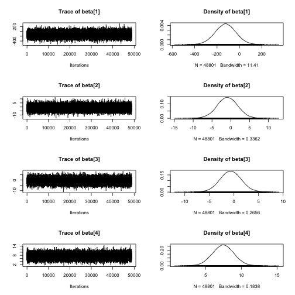

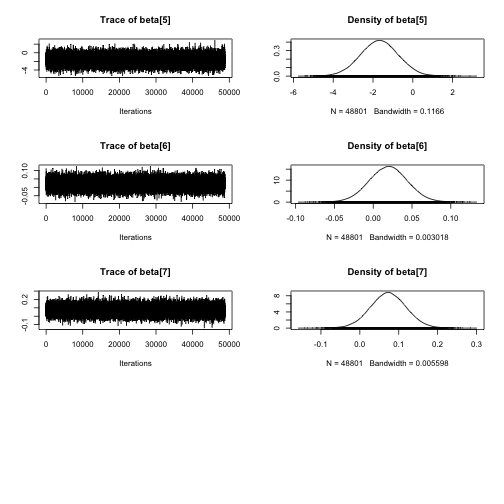

```r
plot(as.mcmc(loyn.r2jags2$BUGSoutput$sims.matrix[,1:7]))
```

BTW, the parameters are normally arranged in alphabetical order, so it is a good idea to make sure all the one you are interested in (e.g. beta) are before other studd alphabetically. JAGS also throws in Deviance, but this is usually put in at the end.

Check for autocorrelation

```r
autocorr.diag(as.mcmc(loyn.r2jags2$BUGSoutput$sims.matrix[,c(1:7,9)]))
```

```
##              beta[1]       beta[2]      beta[3]       beta[4]
## Lag 0   1.0000000000  1.0000000000 1.0000000000  1.0000000000
## Lag 1  -0.0034959667  0.0045494743 0.0005564878  0.0003734223
## Lag 5   0.0067478229  0.0006726002 0.0026549923 -0.0061700323
## Lag 10  0.0008315104  0.0022944325 0.0022112913 -0.0058832267
## Lag 50 -0.0002163488 -0.0050211099 0.0039649221 -0.0013151119
##              beta[5]       beta[6]       beta[7]         sigma
## Lag 0   1.0000000000  1.0000000000  1.000000e+00  1.0000000000
## Lag 1  -0.0022975685 -0.0118558538 -2.941502e-03 -0.0009093866
## Lag 5   0.0047833007 -0.0028170656  5.479705e-03  0.0009092211
## Lag 10  0.0007394574  0.0007690748  9.813183e-05 -0.0030403735
## Lag 50 -0.0070120378  0.0056205137  1.076503e-04 -0.0017053282
```

No evidence of autocorrelation.

```r
#print(loyn.r2jags)
```

The first beta will be the intercept. After that, you need to remember what order you put the predictors in the model.matrix. Recall

```
X <- model.matrix(~logDIST+logLDIST+logAREA+GRAZE+ALT+YR.ISOL,data=loyn)
head(X)
```

ANOVA